# U.S. trends in prescription nonsteroidal anti‐inflammatory drug use among patients with cardiovascular disease, 1988–2016 - Hwang - 2021 - Pharmacotherapy: The Journal of Human Pharmacology and Drug T

[Pharmacotherapy: The Journal of Human Pharmacology and Drug Therapy](https://accpjournals.onlinelibrary.wiley.com/journal/18759114)

[Volume 41, Issue 3](https://accpjournals.onlinelibrary.wiley.com/toc/18759114/2021/41/3) p. 247-256

[figure not shown]

ORIGINAL RESEARCH ARTICLE

Full Access

# U.S. trends in prescription nonsteroidal anti-inflammatory drug use among patients with cardiovascular disease, 1988–2016

[Andrew Y. Hwang](https://accpjournals.onlinelibrary.wiley.com/action/doSearch?ContribAuthorRaw=Hwang%2C+Andrew+Y),

[Steven M. Smith](https://accpjournals.onlinelibrary.wiley.com/action/doSearch?ContribAuthorRaw=Smith%2C+Steven+M),

First published: 24 November 2020

https://doi.org/10.1002/phar.2488

Citations: 1

**Funding information**

Dr. Smith is funded by the National Heart, Lung and Blood Institute (K01 HL138172).

## Abstract

### Background

Nonsteroidal antiinflammatory drugs (NSAIDs) have been associated with increased risk of adverse cardiovascular events prompting labeling revisions cautioning their use among patients with cardiovascular disease (CVD). However, little is known regarding long-term trends in real-world prescribing of NSAIDs within the CVD population. We aimed to characterize the use of prescription NSAIDs among U.S. adults with CVD from 1988 to 2016.

### Methods

We used the National Health and Nutrition Examination Survey cross-sectional data from 1988–1994 and 19992016 to identify participants aged greater than or equal to 18 years with hypertension (defined by self-report, mean blood pressure ≥ 140/90 mm Hg, or antihypertensive medication use), or aged greater than or equal to 20 years with self-reported congestive heart failure (CHF), coronary heart disease (CHD), angina, myocardial infarction (MI), or stroke. Prevalence of prescription NSAID use was analyzed in 6-year examination periods. Weighted logistic regression was performed to test time trends in prescription NSAID use.

### Results

Overall, prescription NSAID use declined among all CVD populations. The highest prevalence of overall prescription NSAID use was observed during the 1999–2004 examination years, thereafter declining through the 2005–2010 and 2011–2016 examination years: in patients with hypertension (13.9% [1999–2004] to 8.5% [2011–2016]), CHF (14.6%–8.5%), CHD (16.3%–7.4%), angina (17.6%–8.5%), MI (16.1%–9.0%), and stroke (15.7%–7.9%). Decreased use of COX-2-selective inhibitors was observed during the same period; whereas, nonselective NSAID use remained relatively stable. Trends in prescription NSAID use were reflective of the general adult population.

### Conclusions

Prescription NSAID use among patients with CVD appears to have declined from 1988 to 2016, primarily due to reduced COX-2-selective inhibitor use. Nonetheless, the prevalence of prescription NSAIDs has persisted among a subset of high-risk CVD populations.

## 1 INTRODUCTION

Nonsteroidal antiinflammatory drugs (NSAIDs) are commonly prescribed to treat minor pain, fever, or inflammation. Available over-the-counter (OTC) and by prescription, the ubiquitous use of NSAIDs has led to concerns about the increased risk of adverse cardiovascular events, particularly in patients with established cardiovascular disease (CVD).<sup>1-3</sup> In 2005, the U.S. Food and Drug Administration (FDA) suggested labeling revisions for all NSAIDs to warn about the potential increased risk of adverse cardiovascular events. Subsequently, in July 2015, the FDA issued an updated statement that strengthened their previous warning, based on safety data suggesting increased risk of myocardial infarction (MI) and stroke among patients with preexisting CVD.<sup>4</sup> Furthermore, contemporary guidelines have recognized the potential of NSAIDs to interfere with management of hypertension and heart failure, and recommendations have been issued to encourage avoidance of NSAIDs in these populations.<sup>5, 6</sup>

Despite these recommendations to limit NSAID use in high risk populations, the prevalence of NSAID use among patients with CVD is incompletely understood. Prior studies have estimated the use of NSAIDs within the overall U.S. population to be ~12%<sup>7, 8</sup>; and only recently have studies underscored a relatively high prevalence among patients with established CVD.<sup>9-11</sup> Little is still known regarding the long-term trends in NSAID use within the CVD population, particularly as it pertains to the issuance of the FDA warnings. Therefore, we aimed to characterize the trends in the use of prescription NSAID among patients with CVD from 1988 to 2016. Specifically, we focused our investigation on analyzing NSAID use among CVD populations in which NSAIDs should be minimized to the extent possible, due to increased adverse cardiovascular risk.

## 2 METHODS

### 2.1 Study population

We used cross-sectional National Health and Nutrition Examination Survey (NHANES) data to examine the use of prescription NSAIDs among six CVD cohorts: patients with hypertension, congestive heart failure (CHF), coronary heart disease (CHD), angina, MI, and stroke. NHANES uses a complex sampling design to survey the health and nutritional status of both adults and children in the United States.<sup>12</sup> The surveys are carried out in a population-based cluster with random selection to identify a nationally representative sample. Information collected includes self-reported data (e.g., demographic, socioeconomic, dietary, and health-related behaviors), physical examinations, laboratory tests, and prescription medications. These datasets are publicly available through the Centers for Disease Control and Prevention (CDC), and do not contain any patient identifiers. This study was considered exempt from human subject research from the institutional review board at High Point University.

Adult participants aged greater than or equal to 18 years from NHANES III (1988–1994) and the continuous NHANES cycles (1999–2016) were eligible for the study. Specific CVD cohorts were identified among participants aged greater than or equal to 18 years with hypertension or aged greater than or equal to 20 years with established CVD. Hypertension was defined as either (a) self-reported diagnosis of hypertension on two or more office visits, or (b) mean systolic blood pressure (BP) greater than or equal to 140 mm Hg, mean diastolic BP greater than or equal to 90 mm Hg, or self-reported use of prescription medication for hypertension. Established CVD was determined through self-reported affirmative response for at least one of the following conditions: CHF, CHD, angina, MI, or stroke. Participants were grouped into six nonmutually exclusive CVD cohorts – hypertension, CHF, CHD, angina, MI, and stroke.

### 2.2 NSAID exposure

Participants were identified as a prescription NSAID user if they reported use of at least one prescription NSAID, regardless of duration of use. Prescription NSAID information was obtained from the Prescription Medication Questionnaire using the generic drug codes provided by NHANES. We used the Drug Information File to create a list of prescription NSAIDs; the final list consisted of 32 unique generic drug codes (Table S1). NHANES does not distinguish between systemic formulations, therefore, the final list included all prescription NSAIDs regardless of formulation. Aspirin was excluded from the list because low-dose aspirin is indicated for secondary prevention in patients with established CVD. We also excluded topical diclofenac because topical formulations of NSAIDs are often recommended as preferred alternatives to systemic NSAIDs due to their low systemic absorption.

### 2.3 Analysis

Because prescribing patterns may be affected by the type of CVD, we analyzed NSAID use stratified by specific CVD subtype. Trends in prescription NSAID use within each CVD cohort were analyzed in 6-year examination periods to improve statistical precision (i.e., NHANES III [1988–1994] and continuous NHANES cycles [1999–2004, 2005–2010, and 2011–2016]). Due to the lack of self-reported CHD and angina data in NHANES III, analysis of CHD and angina cohorts were restricted to continuous NHANES cycles only. Prescription NSAID use was also assessed within the general adult population, defined as aged greater than or equal to 18 years, to provide a perspective of the trends in context of the overall U.S. adult population. Prevalence estimates for prescription NSAID use were calculated using 6-year sample weights to account for the complex survey design. Estimates were assessed for overall prescription NSAIDs, nonselective NSAIDs, and COX-2-selective inhibitors. The modified Clopper-Pearson method was used to calculate 95% confidence intervals for prevalence estimates. Population counts of NSAID users were calculated by multiplying prevalence estimates with the Current Population Surveys-based population totals provided by the National Center for Health Statistics. Weighted logistic regression was performed to test time trends from 1988–2016, using time as an independent, continuous variable. The midpoint of the NHANES examination periods were designated for the model as follows: 1991 was used for 1988–1994, 2002 was used for 1999–2004, 2008 was used for 2005–2010, and 2014 was use for 2011–2016. Additionally, predictors of prescription NSAID use were examined using weighted multiple logistic regression using the continuous NHANES cycles combined into an 18-year period (1999–2016). Reference groups used in the regression analysis were patients without the relevant CVD. A single regression model was developed for each dependent variable (i.e., overall NSAIDs, nonselective NSAIDs, and COX-2-selective inhibitors), in which each individual CVD subtype was included as an independent variable. The regression model was also adjusted for the following covariates: age, sex, race/ethnicity, body mass index, self-reported health status, smoking status, self-reported chronic obstructive pulmonary disease (COPD), self-reported arthritis, and chronic kidney disease (CKD). The estimated glomerular filtration rate (eGFR), calculated by the modification of diet in renal disease equation, was used to categorize CKD severity as mild (eGFR ≥ 60 ml/min/1.73 m<sup>2</sup> with urinary albumin-to-creatinine ratio ≥30 mg/g) or moderate to severe (eGFR < 60 ml/min/1.73 m<sup>2</sup>, regardless of albumin-to-creatinine ratio). All analyses were done using SAS version 9.4 (SAS Institute).

## 3 RESULTS

### 3.1 Cohort characteristics

Characteristics of the study populations are summarized by NHANES 6-year periods in the individual CVD cohorts (Table 1). Among participants in the hypertension cohort, demographic characteristics (i.e., age, gender, and race/ethnicity) remained largely consistent across NHANES periods. Overall, approximately half of patients with hypertension were aged greater than or equal to 60 years and slightly more than half were women. An increasing trend in the proportion of self-reported history of diabetes and arthritis was observed from the 1988–1994 to 2011–2016 examination periods, whereas the proportion with established CVD remained stable throughout the study period.

TABLE 1. Characteristics (weighted) of General Adult Population and Adult Population With Cardiovascular Diseases, Stratified by NHANES Study Periods

|  | General adult population NHANES study period 1988–1994 | General adult population NHANES study period 1999–2004 | General adult population NHANES study period 2005–2010 | General adult population NHANES study period 2011–2016 | Hypertension NHANES study period 1988–1994 | Hypertension NHANES study period 1999–2004 | Hypertension NHANES study period 2005–2010 | Hypertension NHANES study period 2011–2016 |
| --- | --- | --- | --- | --- | --- | --- | --- | --- |
| Sample *n* (weighted *N*) | 19,255 (180,859,529) | 17,061 (208,576,407) | 18,318 (222,364,573) | 17,969 (236,631,221) | 5602 (48,956,694) | 5510 (65,532,074) | 6503 (72,742,902) | 6564 (82,185,578) |
| Age, yrs |  |  |  |  |  |  |  |  |
| ≤ 39 | 48.1% | 41.8% | 39.6% | 38.2% | 18.6% | 13.4% | 12.5% | 12% |
| 40–59 | 30.1% | 36.5% | 37.4% | 35.8% | 33.4% | 39.7% | 39.8% | 38.2% |
| ≥ 60 | 21.8% | 21.7% | 22% | 26% | 48% | 46.9% | 47.7% | 49.8% |
| Female | 52.2% | 52% | 51.7% | 51.8% | 52.7% | 53.7% | 51.9% | 52% |
| Race/ethnicity |  |  |  |  |  |  |  |  |
| NH White | 76.2% | 70.7% | 69.4% | 64.9% | 77.7% | 73.6% | 72.3% | 68.1% |
| NH Black | 11.1% | 11% | 11.5% | 11.6% | 13.5% | 13.2% | 14.4% | 14.3% |
| Mexican American | 5.2% | 7.4% | 8.4% | 8.8% | 3.5% | 4.4% | 5.2% | 6% |
| Other | 7.5% | 10.9% | 10.7% | 14.7% | 5.3% | 8.8% | 8.1% | 11.6% |
| Comorbidities |  |  |  |  |  |  |  |  |
| Diabetes | 5.3% | 6.7% | 8% | 9.7% | 11.4% | 14.6% | 17.4% | 20.6% |
| Hypertension | 27.1% | 31.5% | 32.7% | 34.7% | – | – | – | – |
| Established CVD |  |  |  |  |  |  |  |  |
| CHF | 2.2% | 2.4% | 2.3% | 2.6% | 5.6% | 5.1% | 5.3% | 6% |
| CHD | – | 3.5% | 3.3% | 3.4% | – | 8% | 7.2% | 7.3% |
| Angina | – | 3.1% | 2.2% | 2.1% | – | 6.8% | 4.9% | 4.6% |
| MI | 3.5% | 3.6% | 3.3% | 3.3% | 8.1% | 7.4% | 7% | 7.1% |
| Stroke | 2.1% | 2.6% | 2.9% | 2.8% | 4.9% | 6% | 6.6% | 6.2% |
| CKD |  |  |  |  |  |  |  |  |
| Mild | 8.3% | 7.2% | 7% | 7.6% | 13.7% | 11.4% | 10.9% | 11.5% |
| Moderate-to-severe | 10.4% | 7.9% | 7.9% | 8.5% | 18.7% | 18% | 17.7% | 17.4% |
| Arthritis | 17.7% | 22.5% | 24.6% | 25.4% | 33.2% | 39.3% | 41.6% | 43.1% |

| Characteristic | CHF NHANES study period 1988–1994 | CHF NHANES study period 1999–2004 | CHF NHANES study period 2005–2010 | CHF NHANES study period 2011–2016 | CHD NHANES study period 1999–2004 | CHD NHANES study period 2005–2010 | CHD NHANES study period 2011–2016 |
| --- | --- | --- | --- | --- | --- | --- | --- |
| Sample *n* (weighted *N*) | 745 (4,019,583) | 551 (4,776,651) | 571 (4,948,551) | 583 (5,956,565) | 707 (7,068,591) | 707 (6,995,516) | 672 (7,703,503) |
| Age, yrs |  |  |  |  |  |  |  |
| ≤ 39 | 5.3% | 4.6% | 4% | 4.4% | 2.4% | 2.4% | 2.3% |
| 40–59 | 21.6% | 27.5% | 22.8% | 21.6% | 28.3% | 23.2% | 18.2% |
| ≥ 60 | 73.1% | 67.9% | 73.2% | 74% | 69.3% | 74.4% | 79.5% |
| Female | 50.5% | 49.5% | 45.1% | 52.7% | 37.3% | 31.6% | 39.5% |
| Race/ethnicity |  |  |  |  |  |  |  |
| NH White | 73.8% | 77% | 71.5% | 68.7% | 84.4% | 82.1% | 76.8% |
| NH Black | 12.6% | 11.5% | 16.9% | 15.2% | 6.5% | 6.2% | 7.7% |
| Mexican American | 5.3% | 3.3% | 3.4% | 5.5% | 2.5% | 4.5% | 3.7% |
| Other | 8.3% | 8.2% | 8.2% | 10.6% | 6.6% | 7.2% | 11.8% |
| Comorbidities |  |  |  |  |  |  |  |
| Diabetes | 25.9% | 30.6% | 38.4% | 39% | 24.4% | 30.4 | 34.3% |
| Hypertension | 70.4% | 70.8% | 77.5% | 82.7% | 71.4% | 74.5% | 76.7% |
| Established CVD |  |  |  |  |  |  |  |
| CHF | – | – | – | – | 29.5% | 26.5% | 30.4% |
| CHD | – | 44.6% | 38.1% | 39.9% | – | – | – |
| Angina | – | 34.1% | 24.9% | 23.8% | 44% | 34.8% | 32.6% |
| MI | 55.2% | 46.6% | 45.7% | 40.4% | 53.6% | 50.1% | 48.8% |
| Stroke | 19.2% | 17.9% | 21.5% | 20.2% | 13.6% | 15.5% | 15.5% |
| CKD |  |  |  |  |  |  |  |
| Mild | 12.5% | 12.9% | 12.3% | 15.9% | 11.9% | 12.3% | 12.2% |
| Moderate-to-severe | 38.3% | 40.6% | 39.4% | 42.6% | 29.6% | 29.7% | 33.7% |
| Arthritis | 56.4% | 60.7% | 58.5% | 61.2% | 53.4% | 54.1% | 57.9% |

| Characteristic | Angina NHANES study period 1999–2004 | Angina NHANES study period 2005–2010 | Angina NHANES study period 2011–2016 | MI NHANES study period 1988–1994 | MI NHANES study period 1999–2004 | MI NHANES study period 2005–2010 | MI NHANES study period 2011–2016 |
| --- | --- | --- | --- | --- | --- | --- | --- |
| Sample *n* (weighted *N*) | 591 (6,122,343) | 474 (4,635,956) | 398 (4,920,041) | 928 (6,266,263) | 753 (7,200,724) | 758 (7,118,892) | 684 (7,538,112) |
| Age, yrs |  |  |  |  |  |  |  |
| ≤ 39 | 3% | 4% | 4.6% | 3.1% | 3.1% | 4.5% | 2.7% |
| 40–59 | 34.1% | 27.1% | 28.7% | 24.2% | 29.8% | 28.8% | 26.1% |
| ≥ 60 | 62.9% | 68.9% | 66.7% | 72.7% | 67.1% | 66.7% | 71.2% |
| Female | 48.4% | 45.6% | 48.2% | 37.7% | 37.4% | 36.1% | 40.4% |
| Race/ethnicity |  |  |  |  |  |  |  |
| NH White | 83.9% | 77.6% | 79.7% | 84.2% | 81.9% | 79% | 74.1% |
| NH Black | 5.5% | 8.8% | 7.9% | 8.9% | 9.1% | 10.1% | 9.4% |
| Mexican American | 2.9% | 5.4% | 3.5% | 2.5% | 2.7% | 3.7% | 4.5% |
| Other | 7.7% | 8.2% | 8.9% | 4.4% | 6.3% | 7.2% | 12% |
| Comorbidities |  |  |  |  |  |  |  |
| Diabetes | 23.9% | 31.3% | 36.8 | 20.6% | 22.6% | 28.7% | 33.5% |
| Hypertension | 71.4% | 75.3% | 75.6% | 62.4% | 68% | 70.4% | 77% |
| Established CVD |  |  |  |  |  |  |  |
| CHF | 26.2% | 26% | 29% | 35.8% | 31.1% | 32% | 32.3% |
| CHD | 50.9% | 52.2% | 51.8% | – | 54.4% | 50.4% | 51.6% |
| Angina | – | – | – | – | 43.2% | 32.8% | 28.6% |
| MI | 50.1% | 49.4% | 43.6% | – | – | – | – |
| Stroke | 15.8% | 16.6% | 15.1% | 15.7% | 14.7% | 18.4% | 17.3% |
| CKD |  |  |  |  |  |  |  |
| Mild | 9.7% | 10.7% | 14.6% | 11.7% | 10.4% | 10.8% | 12.9% |
| Moderate-to-severe | 30.1% | 29.1% | 29.5% | 31% | 29.5% | 29.1% | 33.1% |
| Arthritis | 61.1% | 59.8% | 64.8% | 53.2% | 53.6% | 55.3% | 59% |

| Characteristic | Stroke NHANES study period 1988–1994 | Stroke NHANES study period 1999–2004 | Stroke NHANES study period 2005–2010 | Stroke NHANES study period 2011–2016 |
| --- | --- | --- | --- | --- |
| Sample *n* (weighted *N*) | 644 (3,816,172) | 606 (5,174,391) | 678 (6,235,528) | 640 (6,460,668) |
| Age, yrs |  |  |  |  |
| ≤ 39 | 5.3% | 7.7% | 5% | 5.5% |
| 40–59 | 21% | 25.6% | 27.4% | 26.2% |
| ≥ 60 | 73.7% | 66.7% | 67.6% | 68.3% |
| Female | 50.3% | 57.9% | 57.8% | 54.2% |
| Race/ethnicity |  |  |  |  |
| NH White | 79.1% | 73.2% | 74% | 66.5% |
| NH Black | 12.8% | 14.5% | 15% | 15.1% |
| Mexican American | 2.2% | 3.6% | 4% | 5.6% |
| Other | 5.9% | 8.7% | 7% | 12.8% |
| Comorbidities |  |  |  |  |
| Diabetes | 25.1% | 22.2% | 30.1% | 30.3% |
| Hypertension | 67.9% | 75.3% | 76.2% | 77.5% |
| Established CVD |  |  |  |  |
| CHF | 20.2% | 16.8% | 17.1% | 18.8% |
| CHD | – | 19% | 17.6% | 18.8% |
| Angina | – | 18.8% | 12.4% | 11.7% |
| MI | 25.9% | 20.5% | 21.1% | 20.2% |
| Stroke | – | – | – | – |
| CKD |  |  |  |  |
| Mild | 17% | 13.1% | 12.7% | 12% |
| Moderate-to-severe | 30.9% | 33.5% | 35.6% | 33.3% |
| Arthritis | 47.9% | 55.9% | 59.5% | 51.3% |

- Abbreviations: CHD = coronary heart disease; CHF = congestive heart failure; CKD = chronic kidney disease; CVD = cardiovascular disease; MI = myocardial infarction; NH = non-Hispanic.

Among participants in the established CVD cohorts, the demographic characteristics and comorbidities remained largely consistent during the study period. Across all CVD cohorts, large majorities of patients were aged greater than or equal to 60 years. Approximately half of the patients in the CHF, angina, and stroke cohorts were women, whereas a majority of patients in the CHD and MI cohorts were men. Compared with the hypertension cohort, patients with established CVD were older and had higher prevalence of moderate to severe CKD and arthritis.

### 3.2 Prevalence of NSAID use

The estimated prevalence and population counts of prescription NSAID use among each cohort are displayed and summarized in Figure 1 and Table S2. A consistent increase in prevalence of prescription NSAID use was noted from 1988–1994 to 1999–2004 among the hypertension, CHF, MI, and stroke cohorts. The highest prevalence of prescription NSAID use among all CVD cohorts was observed during the 1999–2004 examination period. Thereafter, use of prescription NSAIDs sharply declined during the 2005–2010 examination period. This trend was consistent across all six CVD cohorts: overall prescription NSAID use among adults with hypertension (13.9% [1999–2004] to 8.8% [2005–2010]), CHF (14.6%–8.5%), CHD (16.3%–7.0%), angina (17.6%–9.7%), MI (16.1%–8.2%), and stroke (15.7%–8.8%). Prescription NSAID use remained generally stable from the 2005–2010 to 2011–2016 examination periods; at which point, prescription NSAID users represented ~7 million adults with hypertension, 509 thousand adults with CHF, 571 thousand adults with CHD, 417 thousand adults with angina, 678 thousand adults with MI, and 512 thousand adults with stroke (Table S2). The overall results were reflective of the trends seen within the general adult population. Overall prevalence of prescription NSAIDs was similar across CVD cohorts but was notably higher than the general adult population (Figure S1).

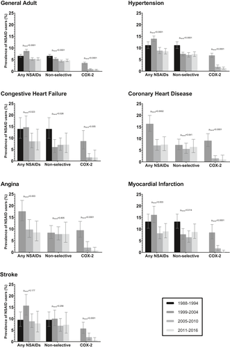

**FIGURE 1**

Weighted prevalence estimates of overall prescription NSAIDs, nonselective NSAIDs, and COX-2-selective inhibitors from 1988–2016 within each study cohort. Error bars indicate 95% confidence interval of the estimates. NSAIDs, nonsteroidal antiinflammatory drugs.

In analyses stratified on NSAID type, prescription nonselective NSAID use remained consistent among all CVD cohorts from 1999–2004 to 2011–2016 examination periods. Conversely, the prevalence of COX-2-selective inhibitors decreased substantially from the 1999–2004 to 2005–2010 examination periods and remained consistently low during the 2011–2016 examination period. This trend was observed in all CVD cohorts: prevalence of COX-2-selective inhibitors use in adults with hypertension (6.7% [1999–2004] to 1.3% [2011–2016]), CHF (8.6%–1.5%), CHD (9.1%–1.0%), angina (9.5%–0.7%), MI (8.5%–0.2%), and stroke (5.7%–0.6%). Sensitivity analysis of 2-year continuous NHANES study periods showed similar trends for overall prescription NSAIDs, nonselective NSAIDs, and COX-2-selective inhibitors (Tables S3 and S4).

### 3.3 Predictors of NSAID use by CVD status

Table 2 and Table S5 summarize predictors of prescription NSAID use by CVD status. Compared with patients without hypertension, patients with hypertension were more likely to be prescribed any NSAID (adjusted odds ratio [aOR], 1.27; 95% confidence interval [CI], 1.13–1.42) and nonselective NSAIDs (aOR 1.26; 95% CI, 1.09–1.45). In contrast, CHF was associated with decreased likelihood of using any prescription NSAIDs (aOR, 0.73; 95% CI, 0.56–0.96) and nonselective prescription NSAIDs (aOR, 0.70; 95% CI, 0.50–0.97) compared with patients without CHF. No significant associations were observed for use of overall prescription NSAIDs or nonselective prescription NSAIDs with the presence of CHD, angina, MI, or stroke. COX-2-selective inhibitor use was less likely among patients with stroke (aOR, 0.60; 95% CI, 0.39–0.92); however, no significant associations were seen with the other CVDs.

TABLE 2. Predictors of NSAID use by CVD Status Among Adults From 1999–2016

|  | Overall NSAIDs aOR (95% CI)<sup>a</sup> | Non-selective NSAIDs aOR (95% CI)<sup>a</sup> | COX-2-selective aOR (95% CI)<sup>a</sup> |
| --- | --- | --- | --- |
| HTN<sup>b</sup> | 1.27 (1.13, 1.42)* | 1.26 (1.09, 1.45)* | 1.19 (0.97, 1.46) |
| CHF<sup>b</sup> | 0.73 (0.56, 0.96)* | 0.70 (0.50, 0.97)* | 0.83 (0.51, 1.36) |
| CHD<sup>b</sup> | 0.94 (0.74, 1.19) | 0.84 (0.63, 1.12) | 1.14 (0.76, 1.71) |
| Angina<sup>b</sup> | 1.01 (0.77, 1.32) | 0.95 (0.69, 1.29) | 1.13 (0.72, 1.76) |
| MI<sup>b</sup> | 0.95 (0.74, 1.23) | 1.05 (0.78, 1.40) | 0.81 (0.53, 1.24) |
| Stroke<sup>b</sup> | 0.83 (0.63, 1.08) | 0.96 (0.71, 1.28) | 0.60 (0.39, 0.92)* |

- Abbreviations: aOR = adjusted odds ratio; CI = confidence interval; CHD = coronary heart disease; CHF = congestive heart failure; CVD = cardiovascular disease; HTN = hypertension; MI = myocardial infarction; NSAID = nonsteroidal antiinflammatory drug.
- <sup>a</sup> Adjusted for age, sex, race/ethnicity, body mass index, self-reported health status, smoking status, self-reported comorbidities (chronic obstructive pulmonary disease [COPD] and arthritis), and chronic kidney disease (full model results available in the Supporting Information).
- <sup>b</sup> Reference was patients without the respective CVD.
- * *p* < 0.05.

## 4 DISCUSSION

Over the past 2 decades, increasing evidence of cardiovascular risk associated with NSAIDs has spurred labeling changes by the FDA to caution against their use in patients with CVD. However, whether these changes have influenced the use of prescription NSAIDs among specific CVD populations is not well understood. Accordingly, we used a nationally representative sample of noninstitutionalized American adults to assess temporal trends in prescription NSAIDS within six CVD cohorts – hypertension, CHF, CHD, angina, MI, and stroke. Notably, we showed that overall trends in prescription NSAID use among all CVD populations declined, most significantly in the late 2000s, and primarily because of substantially reduced use of COX-2-selective inhibitors. To our knowledge, this is the first study to assess the long-term trends of NSAID use within specific CVD populations in the United States.

The results of our study indicate a decreasing trend in the use of prescription NSAIDs among patients with CVD, with a considerable decline in use comparing the 1999–2004 to 2005–2010 examination periods. This sharp decline was driven by a reduction in COX-2-selective inhibitor use during this time period, coinciding with the withdrawal of two COX-2-selective inhibitors, rofecoxib and valdecoxib, from the U.S. market, and well-publicized concerns regarding potential increased risk of adverse cardiovascular events with COX-2-selective inhibitors, more generally. A previous study using claims data found a similar decline in the prescriptions for COX-2-selective inhibitors within the general population.<sup>13</sup> The investigators also noted an increase in the prescriptions for nonselective NSAIDs after withdrawal of rofecoxib and valdecoxib. Conversely, we found consistent use of prescription nonselective NSAIDs over time, with similar trends observed in both CVD cohorts and the general adult population. Our results may be reflective of a more cautious approach to prescribing NSAIDs among both the general adult and CVD populations, given the increasing evidence underscoring the harmful cardiovascular effects of NSAIDs.<sup>3, 6, 14</sup>

Despite a declining trend overall, it is noteworthy that prescription NSAIDs continue to be used among a subset of these CVD populations. Our results indicate that prescription NSAID users represent roughly half a million U.S. adults within the high-risk CVD populations (i.e., CHF, CHD, angina, MI, and stroke). Previous studies also have noted regular use of NSAIDs among patients with CVD.<sup>9-11</sup> A study performed in the United Kingdom found consistent prescribing patterns of NSAIDs in patients with CVD from 2002 to 2010.<sup>11</sup> Another study using administrative claims databases from 2012 to 2016 observed a median NSAID prescribing rate of 11% among patients with hypertension, CHF, or CKD.<sup>9</sup> Our study adds to the current understanding of NSAID use within the CVD population by examining 30-year trends within specific CVD populations, namely those in which NSAIDs are advised to be avoided. We found that prevalence of prescription NSAIDs was similar across the different CVD cohorts (Figure S1), suggesting use remains prevalent regardless of the CVD subtype and even in those at highest risk of cardiovascular events.

We found notable associations between CVD status and prescription NSAID use. As expected, patients with CHF were less likely to be using any prescription NSAIDs and nonselective NSAIDs. Similarly, patients with stroke were less likely to be using prescription COX-2 selective inhibitors. These results may reflect clinician awareness of the potential cardiovascular effects of NSAIDs in patients with established CVD, and, accordingly, limiting their use within this high-risk population. Interestingly, we observed an increased likelihood of prescription NSAID use among patients with hypertension. In general, patients with any CVD likely represent a sicker population than the general public and thus have a higher probability of being treated with most drugs, including NSAIDs. However, a possible explanation for our observation of increased prescription NSAID use in those with hypertension, but decreased use in some other CVD states, is that clinicians may perceive a lower risk among patients with hypertension compared with those with established CVD, and, therefore, may be less inclined to avoid NSAID use in those with hypertension. Previous studies have underscored the BP-increasing effects and cardiovascular safety of NSAIDs within the hypertensive population<sup>1, 15, 16</sup>; however, little is currently known regarding the optimal risk/benefit ratio of prescribing NSAIDs in this population. Understanding the optimal risk/benefit ratio may assist clinicians to make more informed decisions regarding whether there are specific patients with hypertension in whom the benefits of NSAID use outweigh the risk of a cardiovascular event, particularly if use is limited to short-term.

A major strength of this study is the use of a nationally representative survey of the U.S. population over multiple examination periods spanning nearly 30 years. NHANES includes detailed measurements of self-reported and clinical information, allowing for determination of hypertension status using both self-reported questionnaires and clinical thresholds of elevated BP. Another strength of this study is the analysis of long-term trends in prescription NSAID use among six CVD subtypes. We were able to focus our investigation within individual CVD subtypes by combining multiple examination periods, and thus, improving the statistical reliability of the estimates. Nonetheless, this study also has noteworthy limitations. First, the NHANES examination periods that were included in this study do not provide data on OTC medication use; therefore, our results are only representative of prescription NSAID use. Based on a previous cross-sectional report, overall prevalence of NSAID use within this population is likely considerably higher.<sup>10</sup> Second, because we combined examination periods into 6-year increments, our results may obscure trends in prescribing data. However, sensitivity analyses using 2-year examination periods indicated similar patterns of NSAID use (Tables S3 and S4). Third, self-reported information was used to define most of the CVD cohorts, creating the potential for misclassification of individuals (i.e., failure to identify some patients with CVD as such).

## CONFLICTS OF INTEREST

The authors declare no conflicts of interest.

[figure not shown]

March 2021

Pages 247-256